# Analizando datos sobre diversidad sexual

Sociología General  
Grado en Ciencias Políticas y de la Administración  
1º A

## PoliSocioLAB

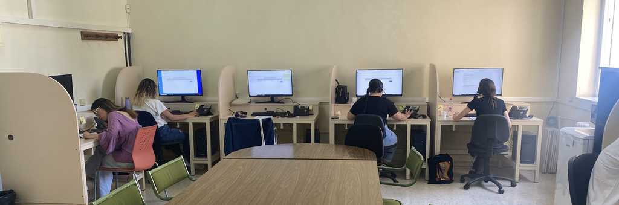

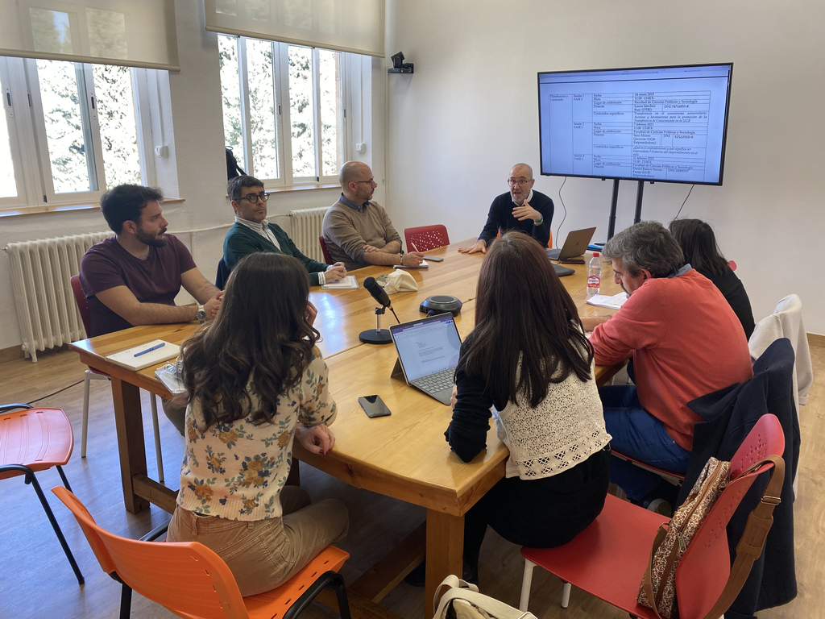

[figure not shown]

[figure not shown]

Más información polisocio.ugr.es/investigacion/polisociolab

## ¿Qué vamos a hacer en esta clase?

A partir de un estudio reciente del CIS sobre diversidad sexual, trabajaremos **en grupos** para:

1. Formular una **pregunta de investigación**.
2. Definir un **objetivo**.
3. Identificar **variables relevantes**.
4. Realizar un **análisis univariable y bivariable** directamente en la web del CIS.
5. Sacar **conclusiones** a partir de los datos.
6. **Exponer el trabajo** al final de la clase.

## ¿Qué es el CIS?

**Centro de Investigaciones Sociológicas (CIS)**

Organismo público dedicado al **estudio científico de la sociedad española**.

**1963** · Origen: Instituto de la Opinión Pública.

**1977** · Pasa a llamarse Centro de Investigaciones Sociológicas.

**¿Qué hace?**

Realiza estudios mediante distintas técnicas de investigación:

- **Cuantitativas:** principalmente encuestas.
- **Cualitativas:** entrevistas, grupos de discusión, etc.

**En Ciencia Política lo conocemos por…**

- **Barómetros mensuales:** una fotografía periódica de la opinión pública.
- **Estudios electorales:** encuestas preelectorales y postelectorales.

El CIS también estudia **muchos otros aspectos de la sociedad**.

**Hoy trabajaremos con un estudio sobre diversidad sexual.**

## ¿Cómo acceder a los estudios del CIS?

Los estudios del CIS son **públicos** y están disponibles **de forma gratuita** para que podáis consultarlos y trabajar con sus datos.

## Pasos de la actividad

## ¿Cómo formular una pregunta de investigación?

**Toda investigación empieza con una curiosidad o inquietud:** algo de la sociedad que nos llama la atención y queremos entender mejor.

Curiosidad → Pregunta concreta → Datos → Respuesta

**Una buena pregunta…**

- Se centra en **algo concreto**.
- **No presupone la respuesta**.
- Puede responderse con **datos o evidencia**.
- Es **clara y específica**.

**En esta actividad**

En esta práctica formularemos una pregunta que podamos responder **comparando o relacionando dos variables**.

**Ejemplo**

**Interés general:** diversidad sexual

**Aspecto concreto:** religiosidad y sexualidad

**Pregunta:** ¿Qué relación existe entre la religiosidad y el número de personas con las que se ha mantenido al menos una relación sexual a lo largo de la vida?

Hoy buscamos relaciones o diferencias entre variables, no demostrar causalidad.

## Definir el objetivo y seleccionar variables

**Objetivo**

Analizar la relación entre la religiosidad y el número de parejas sexuales a lo largo de la vida.

**Pregunta de investigación**

¿Qué relación existe entre la religiosidad y el número de personas con las que se ha mantenido al menos una relación sexual a lo largo de la vida?

**¿SEGÚN QUÉ queremos comparar?**

**Variable independiente (VI)**

La que usamos para comparar o explicar.

**Religiosidad**

**¿QUÉ queremos explicar?**

**Variable dependiente (VD)**

Aquello que queremos explicar.

**N.º de parejas sexuales a lo largo de la vida**

**Para recordarlo:** «¿QUÉ cambia SEGÚN QUÉ?» · **QUÉ cambia = VD** · **SEGÚN QUÉ = VI**

[figure not shown]

## Analizar, concluir y presentar

Ya tenemos una **pregunta de investigación**, un **objetivo** y hemos identificado la **variable dependiente** y la **independiente**. Ahora vamos a trabajar con los datos.

**3. Análisis univariable**

**Una sola variable:** buscad frecuencias o porcentajes en las tablas del CIS.

*Ejemplo:* ¿Cómo se distribuye el número de parejas sexuales a lo largo de la vida?

**4. Análisis bivariable**

Cruzad **dos variables**, como religiosidad y número de parejas sexuales. Buscad diferencias o patrones.

*Ejemplo:* ¿Difiere el número de parejas sexuales según la religiosidad?

**5. Escribir la conclusión**

- ¿Qué descubristeis con los datos?
- ¿Qué relación encontrasteis entre las variables?

**6. Preparar la exposición**

Al final de la clase, **cada grupo presentará**:

- Pregunta y objetivo.
- Variables analizadas.
- Resultados principales **en forma de tabla**.
- Conclusión.

## Número de parejas sexuales a lo largo de la vida

CIS · Diversidad sexual (estudio 3568) · Pregunta 18

[figure not shown]

NS: 4,7 % · NC: 3,0 % · Porcentajes originales sobre el total de la muestra (N = 5.005).

**Un pequeño análisis de los datos**

Las respuestas muestran una considerable diversidad en el número de parejas sexuales a lo largo de la vida. La distribución se concentra especialmente en dos perfiles: quienes han tenido una única pareja sexual y quienes han tenido entre 5 y 10. En conjunto, cerca de la mitad de la muestra declara haber tenido entre 1 y 4 parejas, mientras que algo más de cuatro de cada diez personas señalan cinco o más. Los valores más extremos son poco frecuentes, especialmente por encima de las 100 parejas. Por último, debe tenerse en cuenta que un 7,7 % de las personas entrevistadas no responde o declara no saber la respuesta.

## Analizar, concluir y presentar

Ya tenemos una **pregunta de investigación**, un **objetivo** y hemos identificado la **variable dependiente** y la **independiente**. Ahora vamos a trabajar con los datos.

**3. Análisis univariable**

**Una sola variable:** buscad frecuencias o porcentajes en las tablas del CIS.

*Ejemplo:* ¿Cómo se distribuye el número de parejas sexuales a lo largo de la vida?

**4. Análisis bivariable**

Cruzad **dos variables**, como religiosidad y número de parejas sexuales. Buscad diferencias o patrones.

*Ejemplo:* ¿Difiere el número de parejas sexuales según la religiosidad?

**5. Escribir la conclusión**

- ¿Qué descubristeis con los datos?
- ¿Qué relación encontrasteis entre las variables?

**6. Preparar la exposición**

Al final de la clase, **cada grupo presentará**:

- Pregunta y objetivo.
- Variables analizadas.
- Resultados principales **en forma de tabla**.
- Conclusión.

## Religiosidad y número de parejas sexuales

CIS · Diversidad sexual (estudio 3568) · Porcentajes dentro de cada grupo de religiosidad

| N.º de parejas sexuales | Católico/a practicante | Católico/a no practicante | Creyente de otra religión | Agnóstico/a | Indiferente, no creyente | Ateo/a | N.C. | Total |
| --- | --- | --- | --- | --- | --- | --- | --- | --- |
| Ninguna | 2,1 | 1,6 | 4,5 | 1,9 | 4,2 | 4,5 | 0,0 | 2,6 |
| 1 persona | 39,2 | 26,9 | 18,2 | 11,8 | 16,7 | 14,6 | 15,0 | 23,2 |
| 2 personas | 10,4 | 9,8 | 10,7 | 7,4 | 11,6 | 8,4 | 6,6 | 9,5 |
| 3 personas | 8,8 | 9,7 | 6,1 | 8,9 | 10,4 | 7,4 | 5,1 | 8,9 |
| 4 personas | 3,7 | 5,8 | 7,1 | 6,5 | 5,3 | 5,3 | 15,6 | 5,6 |
| Entre 5 y 10 | 15,8 | 23,5 | 30,3 | 32,1 | 24,5 | 26,7 | 14,8 | 24,2 |
| Entre 11 y 20 | 6,3 | 8,8 | 8,3 | 15,4 | 12,8 | 17,5 | 14,9 | 11,1 |
| Entre 21 y 100 | 4,4 | 5,3 | 7,1 | 9,9 | 6,4 | 8,7 | 3,2 | 6,5 |
| Más de 100 | 0,4 | 0,5 | 0,8 | 0,6 | 1,1 | 0,6 | 0,6 | 0,6 |
| NS | 4,6 | 5,6 | 2,0 | 2,8 | 4,3 | 4,6 | 9,1 | 4,7 |
| NC | 4,5 | 2,4 | 4,9 | 2,6 | 2,8 | 1,6 | 15,1 | 3,0 |
| N | 776 | 1.914 | 270 | 639 | 548 | 778 | 80 | 5.005 |

Porcentajes originales del CIS, sin recalcular · NS y NC incluidos · N = 5.005

**¿Qué diferencias observamos?**

Se observa una relación entre la religiosidad y el número de parejas sexuales a lo largo de la vida. Entre las personas católicas practicantes es mucho más frecuente haber tenido una única pareja sexual: ocurre en el 39,2 %, frente al 14,6 % de las personas ateas y el 11,8 % de las agnósticas. En sentido contrario, las categorías correspondientes a un mayor número de parejas tienen más peso entre las personas agnósticas y ateas. Por ejemplo, el 58,0 % de las personas agnósticas y el 53,5 % de las ateas declaran haber tenido cinco o más parejas, frente al 26,9 % de las católicas practicantes. Los datos apuntan, por tanto, a una asociación entre una mayor religiosidad y un menor número de parejas sexuales a lo largo de la vida.

## Analizar, concluir y presentar

Ya tenemos una **pregunta de investigación**, un **objetivo** y hemos identificado la **variable dependiente** y la **independiente**. Ahora vamos a trabajar con los datos.

**3. Análisis univariable**

**Una sola variable:** buscad frecuencias o porcentajes en las tablas del CIS.

*Ejemplo:* ¿Cómo se distribuye el número de parejas sexuales a lo largo de la vida?

**4. Análisis bivariable**

Cruzad **dos variables**, como religiosidad y número de parejas sexuales. Buscad diferencias o patrones.

*Ejemplo:* ¿Difiere el número de parejas sexuales según la religiosidad?

**5. Escribir la conclusión**

- ¿Qué descubristeis con los datos?
- ¿Qué relación encontrasteis entre las variables?

**6. Preparar la exposición**

Al final de la clase, **cada grupo presentará**:

- Pregunta y objetivo.
- Variables analizadas.
- Resultados principales **en forma de tabla**.
- Conclusión.

## Producto final esperado

Al final de la sesión, cada grupo deberá haber **elaborado y expuesto brevemente**:

- **1 pregunta de investigación**
- **1 objetivo claro**
- Variables seleccionadas
- Análisis univariable
- Análisis bivariable
- **Conclusión escrita y compartida en PRADO**